# Part I - Ford GoBike Trip Data

## Univariate Exploration

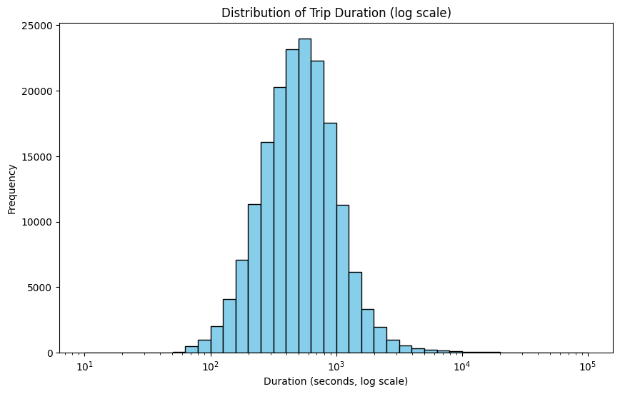

```python
plt.figure(figsize=(10, 6))
bins = 10 ** np.arange(1, np.log10(bike_trips_data_clean['duration_sec'].max()) + 0.1, 0.1)
plt.hist(bike_trips_data_clean['duration_sec'], bins=bins, color='skyblue', edgecolor='black')
plt.xscale('log')  # Using log scale to handle skewness
plt.title('Distribution of Trip Duration (log scale)')
plt.xlabel('Duration (seconds, log scale)')
plt.ylabel('Frequency')
plt.show()
```

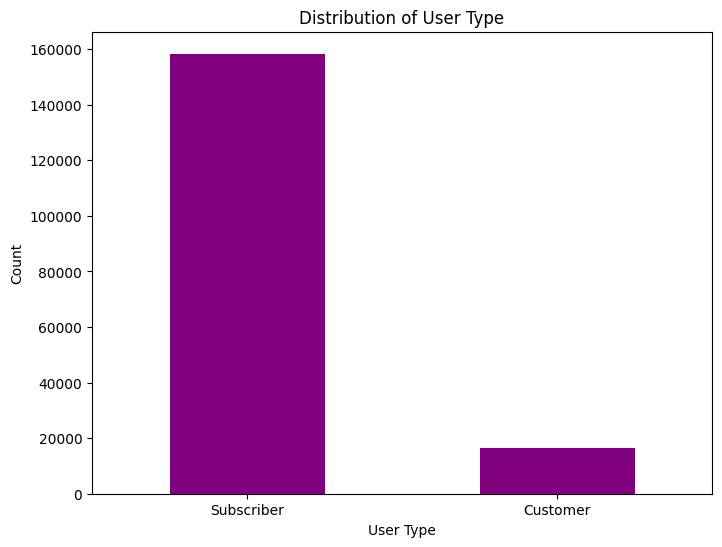

```python
# Bar chart for user type
plt.figure(figsize=(8, 6))
bike_trips_data_clean['user_type'].value_counts().plot(kind='bar', color='purple')
plt.title('Distribution of User Type')
plt.xlabel('User Type')
plt.ylabel('Count')
plt.xticks(rotation=0)
plt.show()
```

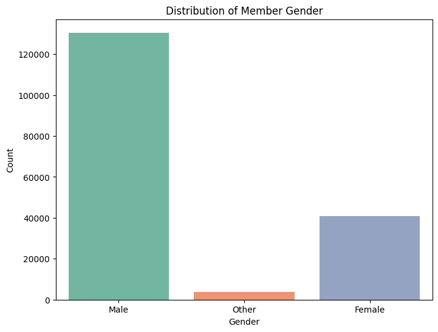

```python
# Count plot for member gender
plt.figure(figsize=(8, 6))
sns.countplot(data=bike_trips_data_clean, x='member_gender', hue='member_gender', palette='Set2', dodge=False)
plt.title('Distribution of Member Gender')
plt.xlabel('Gender')
plt.ylabel('Count')
plt.show()
```

### Discuss the distribution(s) of your variable(s) of interest. Were there any unusual points? Did you need to perform any transformations?

1. Trip Duration (Histogram):
- The distribution of trip duration is heavily right-skewed, with the majority of trips having shorter durations.
- A log scale transformation was applied to handle the skewness and make the data more interpretable in the histogram. No unusual points were observed after this transformation.
2. User Type (Bar Chart):
- The distribution shows that most users are subscribers, while customers account for a smaller proportion.
3. Member Gender (Count Plot):
- The gender distribution indicates a male majority, followed by females. A small "Other" category was also recorded. This distribution aligns with typical user demographic data and shows no anomalies.

### Of the features you investigated, were there any unusual distributions? Did you perform any operations on the data to tidy, adjust, or change the form of the data? If so, why did you do this?

- For trip duration, the right-skewed distribution required a log scale transformation to better visualize the data.
- No transformations were needed for user type or member gender, as their distributions were clear and aligned with expected patterns.

## Bivariate Exploration

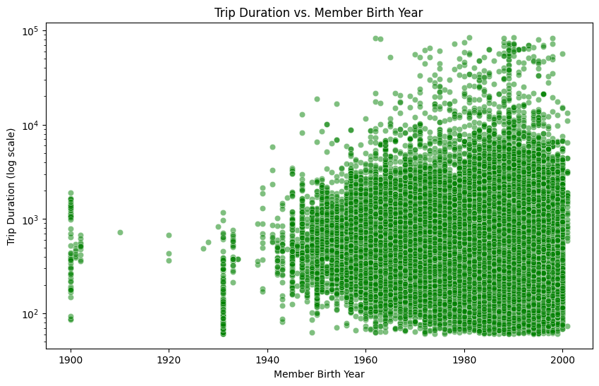

```python
# Scatterplot for trip duration vs. member birth year
plt.figure(figsize=(10, 6))
sns.scatterplot(data=bike_trips_data_clean, x='member_birth_year', y='duration_sec', alpha=0.5, color='green')
plt.yscale('log')  # Log scale for trip duration
plt.title('Trip Duration vs. Member Birth Year')
plt.xlabel('Member Birth Year')
plt.ylabel('Trip Duration (log scale)')
plt.show()
```

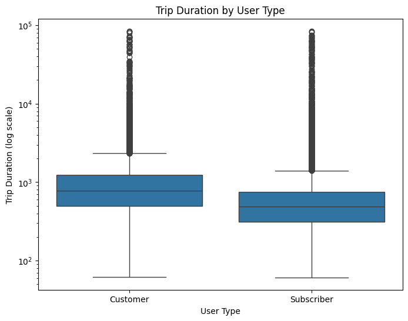

```python
# Box plot for trip duration by user type
plt.figure(figsize=(8, 6))
sns.boxplot(data=bike_trips_data_clean, x='user_type', y='duration_sec')
plt.yscale('log')  # Log scale for better visibility
plt.title('Trip Duration by User Type')
plt.xlabel('User Type')
plt.ylabel('Trip Duration (log scale)')
plt.show()
```

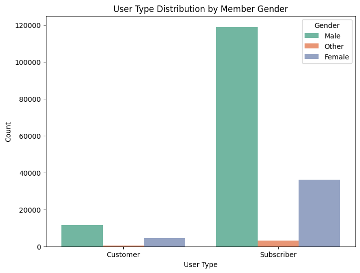

```python
# Clustered bar chart for member gender by user type
plt.figure(figsize=(8, 6))
sns.countplot(data=bike_trips_data_clean, x='user_type', hue='member_gender', palette='Set2')
plt.title('User Type Distribution by Member Gender')
plt.xlabel('User Type')
plt.ylabel('Count')
plt.legend(title='Gender')
plt.show()
```

### Talk about some of the relationships you observed in this part of the investigation. How did the feature(s) of interest vary with other features in the dataset?

- Trip duration varies based on user type: Customers tend to have longer trips than Subscribers.
- Member birth year correlates weakly with trip duration, with younger members showing more variability and older members contributing fewer trips.
- Gender distribution shows that male Subscribers dominate the dataset, but Customers exhibit a more balanced gender distribution.

### Did you observe any interesting relationships between the other features (not the main feature(s) of interest)?

- Male members are the majority across both user types, but the dominance is more pronounced among Subscribers.
- Customers show a higher likelihood of longer trips, which could imply different motivations or purposes for using the service compared to Subscribers.
- Older members contribute fewer trips overall, possibly due to reduced physical activity or different transportation preferences.